# Mortality implications of lower DBP with lower achieved syst... : Journal of Hypertension

Articles

[February 2018 - Volume 36 - Issue 2](https://journals.lww.com/jhypertension/toc/2018/02000)

ORIGINAL PAPERS: Therapeutic aspects

# Mortality implications of lower DBP with lower achieved systolic pressures in coronary artery disease

## long-term mortality results from the INternational VErapamil-trandolapril STudy US cohort

Wokhlu, Anita<sup>a,b,*</sup>; Smith, Steven M.<sup>c,d,*</sup>; Gong, Yan<sup>c</sup>; Handberg, Eileen M.<sup>a</sup>; Elgendy, Islam Y.<sup>a</sup>; Bavry, Anthony A.<sup>a,b</sup>; Cooper-DeHoff, Rhonda M.<sup>a,c,*</sup>; Pepine, Carl J.<sup>a,*</sup>

Author Information

Journal of Hypertension: [February 2018 - Volume 36 - Issue 2 - p 419-427](https://journals.lww.com/jhypertension/toc/2018/02000)

doi: 10.1097/HJH.0000000000001559

- SDC

## Abstract

### Objectives:

A goal SBP 120 mmHg or less reduced mortality in high-risk Systolic Blood Pressure Intervention Trial patients; however, mortality implications of concomitant DBP lowering in coronary artery disease (CAD) are uncertain. We examined the relationship between DBP lowering and all-cause mortality with lower achieved SBPs in a large cohort.

### Methods:

We categorized 17 131 hypertensive patients from the INternational VErapamil-trandolapril STudy US cohort, aged at least 50 years with CAD, by mean achieved SBP (<120, 120 to <130, 130 to <140, and ≥140 mmHg) and DBP tertiles (low, middle, and high per SBP category) during active follow-up. Long-term mortality was determined via National Death Index. Multivariable Cox regression was performed to investigate the impact of DBP lowering among all SBP categories and within each SBP category.

### Results:

There were 6031 deaths over mean follow-up of 11.6 years (198 352 patient-years). In unadjusted analyses, achieving DBP in the lowest tertile portended greatest mortality risk across all SBP categories. In multivariate analysis, using SBP 120 to less than 130 mmHg, DBP at least 79 mmHg as reference (mortality nadir), achieving DBP in the lowest tertile (DBP < 69 mmHg) was associated with excess mortality risk among those with SBP less than 120 mmHg (adjusted hazard ratio 1.60; 95% confidence interval, 1.33–1.91). However, among those with SBP 120 to less than 140 mmHg, adjusted mortality risk did not differ significantly with low DBPs. Among those with SBP at least 140 mmHg, mortality risk remained high regardless of DBP.

### Conclusion:

In older CAD patients, the mortality risk related to excess DBP lowering is accentuated in those achieving intensive SBP control less than 120 mmHg, raising concerns about intensive SBP lowering in these patients.

## INTRODUCTION

The paradigm for managing elevated blood pressure (BP) is evolving, with increasing evidence for a ‘lower is better’ approach relative to prevention of stroke, myocardial infarction (MI), and death <sup>[1]</sup>. However, uncertainty persists over how aggressively to lower BP in older adults (e.g. aged ≥50 years) with coronary artery disease (CAD). Recommended targets of less than 140/90 mmHg in CAD patients and less than 130/80 mmHg in higher risk patients are being reexamined as a result of randomized trials with more intensive SBP lowering demonstrating cardiovascular benefit <sup>[2]</sup>. In a comparison of SBP-lowering strategies to either less than 120 mmHg or to less than 140 mmHg, the Action to Control Cardiovascular Risk in Diabetes (ACCORD) BP trial initially found lower stroke rates with intensive SBP lowering, but no difference in major adverse cardiovascular events <sup>[3]</sup>. However, subsequent analysis accounting for differences in glycemic strategy confirmed cardiovascular event reduction with intensive SBP lowering and standard glycemic treatment <sup>[4]</sup>. Compelling evidence in favor of intensive SBP lowering less than 120 mmHg came from the Systolic Blood Pressure Intervention Trial (SPRINT) of high-risk, nondiabetic patients. The primary outcome (first occurrence of MI, other acute coronary syndrome, heart failure, stroke, or cardiovascular death) was reduced by 25% with intensive BP treatment <sup>[5]</sup> and by 34% in patients aged at least 75 years <sup>[6]</sup>, and reduction in all-cause mortality was also observed.

Even less data exist in the current medical era on appropriate DBP targets, and there is no consensus on the minimum safe level for DBP in patients with CAD. Caution has been recommended for excessive DBP lowering, defined as less than 60 mmHg, in patients with CAD and other high-risk populations because of potential to compromise myocardial perfusion <sup>[2]</sup>. There is also increasing observational evidence for a ‘*J*-curve’ relationship between DBP and cardiovascular risk, in which the reported nadir of cardiovascular risk is a DBP in the 70–89 mmHg range <sup>[11–13]</sup>. However, most previous studies have analyzed the relationship between cardiovascular outcomes and achieved SBP or DBP separately, and few studies have simultaneously incorporated achieved SBP and DBP at an individual patient level in cardiovascular risk assessment <sup>[14]</sup>. Simultaneous incorporation of SBP and DBP into mortality risk assessment, however, is physiologically relevant, particularly in CAD or high cardiovascular risk patients, because benefits of lowering SBP may be offset by risks of excess DBP lowering. Accordingly, the long-term mortality risk associated with DBP lowering, among older CAD patients achieving lower SBP, remains an important knowledge gap. This analysis examines long-term, all-cause mortality risk associated with DBP lowering in CAD patients who achieved various ranges of SBP.

## METHODS

### Study design

The INVEST design, rationale, inclusion and exclusion criteria, and results have been described in detail <sup>[15,16]</sup>. Briefly, this was a multicenter, prospective, randomized controlled trial of hypertensive patients aged at least 50 years with clinically stable CAD. Patients were assigned to either a β-blocker ± hydrochlorothiazide or a calcium antagonist ± angiotensin-converting enzyme inhibitor strategy for BP management. Clinic BP was measured manually at baseline and follow-up visits, per then-current recommendations from the Sixth Report of the Joint National Committee <sup>[15,17]</sup>, and antihypertensive drug therapy was titrated accordingly. Full details of the stepped antihypertensive treatment protocol and BP measurement are in the Supplemental information, https://links.lww.com/HJH/A847. The primary outcome was first occurrence of all-cause mortality, nonfatal MI, or nonfatal stroke. In addition, these individual outcomes and BP control were analyzed as secondary outcomes. Institutional review boards and ethics committees at each site approved the protocol.

Both treatment strategies achieved very similar on-treatment SBP and DBP and overall excellent BP control (72% with BP < 140/90 mmHg) <sup>[7,16]</sup>. After active follow-up (mean duration, 2.7 years), the strategies were equivalent relative to the occurrence of the primary and secondary outcomes, including all-cause mortality. At study completion, patients and providers were informed of these findings, and patients were treated at their provider's discretion. No additional BP data were collected beyond the active follow-up phase. In extended follow-up studies, we continued to observe equivalent mortality comparing treatment groups <sup>[7]</sup>. Accordingly, we combined patients from the two treatment strategies for this extended mortality analysis.

### Outcome

All-cause mortality for US patients was assessed by searching the US National Death Index (NDI) through August 2015, up to 12.5 years after active follow-up was completed. The NDI has been shown to have high validity in discriminating between alive and dead patients <sup>[18,19]</sup>, although there is a known lag time between actual death and inclusion in the NDI, which can lead to underreporting of recent deaths. To be considered a confirmed death, four of five matches among the following were required: name, Social Security number, date of birth, city, and state <sup>[18]</sup>. Patients who did not appear in the NDI were censored on the day the death index search was completed.

### Statistical analysis

For each patient, the mean SBP and DBP achieved on-treatment were calculated using all postbaseline values obtained during active follow-up until the closeout visit or visit before the patient experienced a primary outcome event.

First, each patient was categorized according to mean SBP achieved during active follow-up: SBP less than 120 mmHg, 120 to less than 130 mmHg, 130 to less than 140 mmHg, or at least 140 mmHg. Then patients in each SBP category were subcategorized, according to tertile of DBP achieved, as having a DBP within the low, middle, or high tertiles for their respective SBP category (Fig. 1). This process resulted in assignment of each patient to one of 12 mutually exclusive BP subcategories for analysis.

[figure not shown]

FIGURE 1:

Flow diagram for categorizing INternational VErapamil-trandolapril STudy US cohort participants. Patients were categorized according to achieved SBP averaged over the entirety of active follow-up and subcategorized based on low, middle, and high tertiles of achieved DBP for each SBP category.

Pertinent baseline characteristics of patients in each BP category were compared with the chi-squared test for categorical variables and analysis of variance for continuous variables. Cumulative all-cause mortality was compared among DBP tertiles for each SBP category using a chi-squared test. Kaplan–Meier survival analysis and log-rank tests were used to compare time to all-cause mortality among the DBP tertiles within each SBP category. Multivariable Cox proportional hazard regression was performed to estimate the adjusted hazard ratios and 95% confidence intervals (CIs) for all-cause mortality risk among the 12 BP categories. The referent group was assigned based on the nadir unadjusted mortality risk. All Cox regression analyses were adjusted for prespecified covariates [age, sex, race, history of MI, and congestive heart failure (CHF) New York Heart Association class I–III], as well as covariates that remained in the model after stepwise selection with *P* less than 0.2 to enter and *P* less than 0.05 to retain in the model (i.e. history of stroke/transient ischemic stroke, renal insufficiency, and diabetes mellitus). Achieved heart rate (HR) (average of postbaseline values) was also included because of potential interaction of HR with DBP. Additional multivariate analyses were performed comparing the low, middle, and high DBP tertiles within each SBP category by using the middle DBP tertile as reference. All *P* values were two-tailed, with statistical significance set at less than 0.05. All analyses were performed with SAS 9.3 (SAS Institute, Cary, North Carolina, USA).

## RESULTS

### Patient characteristics

Of the 22 576 patients in INVEST, 17 131 (76%) resided in the United States and comprised the US cohort for which extended follow-up all-cause mortality data were available. The cohort was older, with a mean ± SD age of 66.3 ± 10 years (60.2% were aged 60 to <80 years and 10.4% were ≥80 years), and included 53.8% women. Approximately 30% had diabetes; CHF class I–III was uncommon (5.4%).

At baseline, and with prior antihypertensive drugs, mean SBP was 148.2 ± 19.0 mmHg and DBP was 84.9 ± 11.1 mmHg. With study treatment, 66.7% achieved a mean SBP less than 140 mmHg during active follow-up. A mean SBP less than 120 mmHg was achieved in approximately 6.4% of patients. The median DBP achieved was 78 (interquartile range: 74–83) mmHg in the overall cohort. A mean DBP less than 70 mmHg was observed in 11% of patients. Table 1 summarizes pertinent baseline characteristics by BP category. Across SBP categories, patients with lower DBP were generally older with higher prevalence of diabetes, CHF, previous stroke/transient ischemic attack, or prior MI.

[figure not shown]

TABLE 1:

Characteristics of the US cohort according to blood pressure achieved (mmHg) during active follow-up

### Unadjusted all-cause mortality

Death occurred in 6031 patients (35.2%) over a mean follow-up of 11.6 years, a total of 198 352 patient-years. Across all SBP groups, lower DBP was associated with significantly higher all-cause mortality (Fig. 2). Mortality was highest for patients with SBP less than 120 mmHg in the low DBP tertile (DBP < 69 mmHg). Mortality was also high among those with SBP at least 140 mmHg in the low DBP tertile (DBP < 79 mmHg). Mortality was lowest (22.8%) for patients achieving a SBP 120 to less than 130 mmHg and DBP in the high tertile (≥79 mmHg).

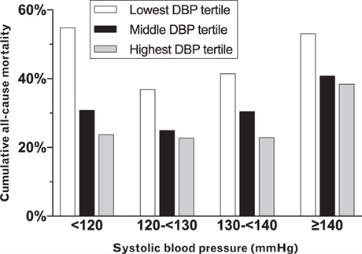

FIGURE 2:

All-cause mortality according to achieved DBP within SBP categories. Within each SBP category, significant differences (*P* < 0.0001) were observed between low, middle, and high DBP tertiles using the chi-squared test.

Kaplan–Meier survival curves are shown in Fig. 3. Within all SBP categories, the low DBP tertiles were associated with higher mortality risk. Among SBP categories, the greatest mortality risk difference among DBP categories was observed in those achieving a SBP less than 120 mmHg. For all SBP categories, the curves noticeably separate within 2 years of follow-up, although in patients with SBP less than 120 mmHg, the mortality differences are apparent by 1 year.

[figure not shown]

FIGURE 3:

Kaplan–Meier survival analysis for all-cause mortality based on achieved blood pressure. Each panel represents a SBP category, highlighted each DBP tertile, with the low tertile shown in red, the middle tertile shown in black, and the high tertile shown in blue. SBP and DBP are in mmHg.

### Adjusted mortality risk across all blood pressure categories

[figure not shown]

FIGURE 4:

Adjusted hazard ratios for all-cause mortality across all blood pressure categories. Mortality risk is compared across different SBP categories with DBP within the low (1), middle (2), or high (3) tertiles within each SBP category, using SBP 120 to less than 130 mmHg, DBP at least 79 mmHg as reference. Hazard ratios were adjusted for average heart rate, age, sex, race, and history of myocardial infarction, diabetes mellitus, congestive heart failure, renal insufficiency, and stroke.

### Adjusted mortality risk within SBP categories

[figure not shown]

FIGURE 5:

Adjusted hazard ratios for all-cause mortality within SBP categories. Mortality risk among low (1), middle (2), and high DBP (3) tertiles, using the middle tertile as reference (gray) is shown for each SBP category. Hazard ratios were adjusted for average heart rate, age, sex, race, and history of myocardial infarction, diabetes mellitus, congestive heart failure, renal insufficiency, and stroke.

## DISCUSSION

Over the past decade, hypertensive management has shifted to progressively more intensive SBP-lowering strategies, with diminishing focus on the potential effects of concomitantly lowering DBP. Our results indicate that the consequences of DBP lowering merit reconsideration in CAD and other high-risk patients aged at least 50 years. With over 6000 deaths in almost 200 000 patient-years of follow-up, we assessed long-term all-cause mortality risk in relation to a period of low, middle, and high achieved DBP tertiles within achieved SBP categories. For each SBP category, unadjusted mortality rates were highest among the low DBP tertiles. After adjusting for relevant covariates, increased mortality risk persisted in those with achieved SBPs of less than 120 mmHg within the low DBP tertile (<69 mmHg), as well as those with poorly controlled SBP (≥140 mmHg), regardless of DBP. In contrast, among those with achieved SBP 120 to less than 140 mmHg, achieving DBPs in the low tertiles was not associated with increased adjusted mortality risk.

Our results indicate that among older patients with CAD, the concomitant lowering of DBP, particularly to less than 69 mmHg, is associated with increased mortality in those with SBP lowering less than 120 mmHg. This finding raises the question of whether greater surveillance to avoid excessively low DBP is required when SBPs less than 120 mmHg are achieved in CAD patients. Another important finding was that mortality risk was not reduced with lower achieved SBPs (<120 mmHg) in CAD patients compared with SBPs in the 120 to less than 130 or 130 to less than 140 mmHg ranges. These results extend our previous INVEST findings on SBP and long-term mortality by specifically assessing mortality in patients with achieved SBP less than 120 mmHg as targeted in SPRINT <sup>[7]</sup>. Whether the combination of low achieved DBP and SBP directly influences mortality or serves as a marker for poor overall health or cardiovascular health status requires further prospective study. Nonetheless, absence of mortality benefit in those with achieved SBP less than 120 mmHg and potential for greater risk among those with SBP less than 120 mmHg and low DBPs suggest that caution should be exercised extrapolating the potential mortality benefits of intensive SBP-lowering strategies to CAD patients.

### Excess DBP lowering: an unintended consequence

Multiple, though not all, studies in this field suggest that cardiovascular risk and mortality risk increase when DBP falls too low <sup>[11–13,20–22]</sup>. In the CLARIFY registry (5-year follow-up, 1890 deaths) of CAD patients, a 1.5-fold increased adjusted mortality risk was observed in patients with DBP 60–69 mmHg relative to those with DBP 70–80 mmHg. A markedly higher risk was noted among those with DBP less than 60 mmHg <sup>[12]</sup>. CLARIFY researchers also observed an increased adjusted mortality risk associated with SBP lowering to less than 120 mmHg. The European Working Party on High Blood Pressure in the Elderly also examined mortality associated with achieved DBP and found that low DBP was associated with higher mortality, but this association was independent of treatment (antihypertensive vs. placebo) <sup>[23]</sup>. In other words, the greater mortality risk associated with low DBP may not be treatment-induced but there were only 135 deaths in 3 years of follow-up. However, few studies address the risks attributable to SBP lowering as it interacts with DBP <sup>[14,23]</sup>. In the placebo-controlled Systolic Hypertension in Europe (Syst-Eur) study (463 deaths) of on-treatment DBP and prognosis in the elderly, low on-treatment DBP less than 70 mmHg was associated with an increased risk of cardiovascular events in the CAD subgroup on active treatment. Inclusion of SBP into regression models did not affect the DBP–cardiovascular risk relationship, but SBP was analyzed as a dichotomous variable <sup>[24]</sup>. The SBP–DBP interaction has been further assessed in studies of pulse pressure (PP) and cardiovascular outcomes; widening PP, like lowering of DBP, has been postulated as a surrogate of increased arterial stiffness and is associated with increased cardiovascular risk <sup>[25]</sup>, particularly in combination with DBPs less than 70 mmHg <sup>[26]</sup>. For our analysis, the focus was maintained on SBP and DBP rather than PP, not only because SBP and DBP are routinely followed in clinical practice, but also because PP was identified as a relatively weaker indicator of cardiovascular outcomes in a previous INVEST analysis <sup>[20]</sup>.

Our present analysis frames earlier findings derived from analyses in which SBP and DBP were decoupled, in a more physiologically relevant context, by simultaneously incorporating achieved SBP and DBP into the risk analysis <sup>[11–13,21]</sup>. Our findings show that previously described risks of ‘excess’ DBP lowering cluster among patients who achieve SBP less than 120 mmHg. Low DBP (i.e. <70 mmHg) is encountered more frequently among those achieving SBP less than 120 mmHg, as occurred in over one-third of these patients vs. approximately one-tenth of the overall cohort. Although the specific mechanism accounting for risk attributable to the combination of low DBP and SBP requires further study, it seems premature to adopt intensive SBP-lowering strategies (<120 mmHg) in older CAD patients with the unresolved issue of monitoring for low DBP. This is particularly relevant when achieving higher SBPs in the 120 to less than 140 mmHg range demonstrates no significant mortality differences among DBP subcategories and appears to confer a mortality benefit compared with SBP at least 140 mmHg.

### Findings in context of other blood pressure-lowering trials

There are limited randomized controlled trial data about mortality implications of strategies targeting (or avoiding) DBPs as low as those observed in the lower tertiles achieved in this study. For example, in the Appropriate Blood Pressure Control in Diabetes trial, intensive DBP lowering (<75 mmHg) was associated with reduced adverse outcomes compared with moderate DBP control (80–89 mmHg); however, there were only 116 CAD patients in the intensive treatment group who achieved a mean BP of 132/78, yielding limited outcome implications of ‘low’ DBP <sup>[27]</sup>. In SPRINT, the intensive treatment group (SBP < 120 mmHg) achieved a mean DBP of 69 mmHg and had better cardiovascular outcomes vs. standard treatment (SBP < 140 mmHg) with a mean DBP of 76 mmHg <sup>[5]</sup>.

Although this analysis is limited by its observational design, these findings raise concern about the effects of DBP, achieved with intensive BP-lowering strategies, in CAD patients who were not sufficiently represented in the SPRINT. INVEST included only CAD patients, 30% of whom also had diabetes, whereas SPRINT included a minority of CAD patients (<20%) and excluded those with diabetes <sup>[1,26]</sup>. From a mechanistic standpoint, myocardial injury (troponin elevation) was associated with DBP lowering less than 60 mmHg in a community-based cohort <sup>[22]</sup>. However, this DBP threshold may differ in hypertensive subpopulations, such as in heart failure or left ventricular hypertrophy <sup>[28]</sup>. Those with CAD appear to have less tolerance for DBP lowering associated with a lower achieved SBP when compared with patients without overt CAD.

### Limitations

INVEST was not designed to test intensive SBP lowering less than 120 mmHg or to compare specific DBP targets, so this study has the limitations of a post-hoc analysis. We acknowledge the potential for reverse causality – that achieving a low DBP is a marker of ill health, which may underlie greater mortality risk. The SBP less than 120 mmHg group with the lowest DBP tertile had greater prevalence of prior MI and also CHF history. Even with a comprehensive approach to adjusting for major confounders, clinical characteristics may have contributed to the risks attributed to excess BP lowering. Furthermore, the increased risk associated with low DBP may include noncardiovascular mortality risk as well, as found in Syst-Eur <sup>[24]</sup>.

In addition, neither BP nor antihypertensive medication use were assessed beyond the period of active trial follow-up. Despite this, a robust association was noted between early low DBPs and increased observed long-term mortality. Similar observations of long-term mortality effect, remote from the active study phase, have been made in other areas of cardiovascular therapeutics <sup>[16,29]</sup>. Although this study provides useful insight in achieved SBP and all-cause mortality, there is additional need to clarify the risk of SBP and DBP-lowering strategies on other major cardiovascular events.

### Summary and conclusion

Whether to pursue intensive management of BP in older CAD patients has broad implications. By extending BP treatment to adults with an SBP 120 to less than 140 mmHg and prior cardiovascular disease or high cardiovascular disease risk, an estimated 14 million US patients would either be classified as treatment-eligible or would require medication intensification <sup>[30]</sup>. In CAD patients with hypertension, the current findings favor achieving SBPs of 120 to less than 140 mmHg and avoidance of the extremes of SBP due to high mortality risks, some of which appear linked with a concomitant low DBP. Adapting strategies to achieve SBPs less than 120 mmHg in hypertensive patients with CAD would be premature, as the cardiovascular impact of DBP lowering requires further prospective study.

## ACKNOWLEDGEMENTS

We thank Negar Nasiri-Kenari and Sarah M. Lima for their help in performing the search for the United States National Death Index used for this study.

Previous presentation: An abstract has been presented at the ACC Scientific Sessions, Washington, District of Columbia, USA, 17–19 March 2017.

The main INVEST [International Verapamil (SR)/Trandolapril Study] was funded by grants from BASF Pharma, Ludwigshafen, Germany; Abbott Laboratories, Abbott Park, Illinois, USA; and the University of Florida Research Foundation and Opportunity Fund, Gainesville, Florida, USA.

### Conflicts of interest

There are no conflicts of interest.

## Reviewers’ Summary Evaluations

### Reviewer 1

Main conclusion of this posthoc analysis of the INVEST trial is that a lower on-treatment diastolic BP is associated with higher mortality in older hypertensive patients with coronary artery disease but that, after adjustment, the increased mortality risk only persists when achieved systolic BP is below 120 mmHg. Limitations for the interpretation are that the trial only included patients with coronary artery disease and that all patients were actively treated so that reverse causality cannot be excluded and the results may not be applicable to other hypertensive patients. Finally, differences in type and conditions of the BP measurement may complicate the issue.

### Reviewer 2

This posthoc observational analysis of INVEST data has obvious limitations in its nature of being planned and performed. However, in the aftermath of the spurious SPRINT data, and the untoward recommendations by the SPRINT investigators and the director of NIH, all large data bases of important treatment trials should be explored for apparent optimal treatment target. This analysis of optimal treatment target in the coronary patients who participated in INVEST suggests that a target SBP as low as 120 mmHg in such high risk patients will increase mortality. Not surprisingly. Soon reports from other large high risk populations will be published and show essentially the same.

## REFERENCES

1. Verdecchia P, Angeli F, Gentile G, Reboldi G. More versus less intensive blood pressure–lowering strategy: cumulative evidence and trial sequential analysis. *Hypertension* 2016; 68:642–653.

- Cited Here |
- [View Full Text](https://journals.lww.com/jgpt/00004268-201609000-00021.fulltext) | [PubMed](http://www.ncbi.nlm.nih.gov/pubmed/27456518) | [CrossRef](https://doi.org/10.1161%2FHYPERTENSIONAHA.116.07608)

2. Rosendorff C, Lackland DT, Allison M, Aronow WS, Black HR, Blumenthal RS, et al. American Heart Association; American College of Cardiology; American Society of Hypertension. Treatment of hypertension in patients with coronary artery disease: a scientific statement from the American Heart Association, American College of Cardiology, and American Society of Hypertension. *J Am Coll Cardiol* 2015; 65:1998–2038.

- Cited Here |
- [PubMed](http://www.ncbi.nlm.nih.gov/pubmed/25840655) | [CrossRef](https://doi.org/10.1016%2Fj.jacc.2015.02.038)

3. Cushman WC, Evans GW, Byington RP, Goff DC Jr, Grimm RH Jr, Cutler JA, et al. ACCORD Study Group. Effects of intensive blood-pressure control in type 2 diabetes mellitus. *N Engl J Med* 2010; 362:1575–1585.

4. Margolis KL, O’Connor PJ, Morgan TM, Buse JB, Cohen RM, Cushman WC, et al. Outcomes of combined cardiovascular risk factor management strategies in type 2 diabetes: the ACCORD randomized trial. 2014; 37:1721–1728.

5. Wright JT Jr, Williamson JD, Whelton PK, Snyder JK, Sink KM, Rocco MV, et al. SPRINT Research Group. A randomized trial of intensive versus standard blood-pressure control. 2015; 373:2103–2116.

6. Williamson JD, Supiano MA, Applegate WB, Berlowitz DR, Campbell RC, Chertow GM, et al. SPRINT Research Group. Intensive vs standard blood pressure control and cardiovascular disease outcomes in adults aged ≥75 years: a randomized clinical trial. 2016; 315:2673–2682.

7. Elgendy IY, Bavry AA, Gong Y, Handberg EM, Cooper-DeHoff RM, Pepine CJ. Long-term mortality in hypertensive patients with coronary artery disease: results from the US cohort of the International Verapamil (SR)/Trandolapril Study. 2016; 68:1110–1114.

8. Kjeldsen SE, Lund-Johansen P, Nilsson PM, Mancia G. Unattended blood pressure measurements in the Systolic Blood Pressure Intervention Trial: implications for entry and achieved blood pressure values compared with other trials. 2016; 67:808–812.

9. Filipovský J, Seidlerová J, Kratochvíl Z, Karnosová P, Hronová M, Mayer O Jr. Automated compared to manual office blood pressure and to home blood pressure in hypertensive patients. 2016; 25:228–234.

10. Myers MG, McInnis NH, Fodor GJ, Leenen FH. Comparison between an automated and manual sphygmomanometer in a population survey. 2008; 21:280–283.

11. Bangalore S, Messerli FH, Wun CC, Zuckerman AL, DeMicco D, Kostis JB, et al. Treating to New Targets Steering Committee and Investigators. -curve revisited: an analysis of blood pressure and cardiovascular events in the Treating to New Targets (TNT) Trial. 2010; 31:2897–2908.

12. Vidal-Petiot E, Ford I, Greenlaw N, Ferrari R, Fox KM, Tardif JC, et al. CLARIFY Investigators. Cardiovascular event rates and mortality according to achieved systolic and diastolic blood pressure in patients with stable coronary artery disease: an international cohort study. 2016; 388:2142–2152.

13. Messerli FH, Mancia G, Conti CR, Hewkin AC, Kupfer S, Champion A, et al. Dogma disputed: can aggressively lowering blood pressure in hypertensive patients with coronary artery disease be dangerous? 2006; 144:884–893.

14. Mancia G, Kjeldsen SE, Zappe DH, Holzhauer B, Hua TA, Zanchetti A, et al. Cardiovascular outcomes at different on-treatment blood pressures in the hypertensive patients of the VALUE trial. 2016; 37:955–964.

15. Pepine CJ, Handberg-Thurmond E, Marks RG, Conlon M, Cooper-DeHoff R, Volkers P, Zellig P. Rationale and design of the International Verapamil SR/Trandolapril Study (INVEST): an Internet-based randomized trial in coronary artery disease patients with hypertension. 1998; 32:1228–1237.

16. Pepine CJ, Handberg EM, Cooper-DeHoff RM, Marks RG, Kowey P, Messerli FH, et al. INVEST Investigators. A calcium antagonist vs a noncalcium antagonist hypertension treatment strategy for patients with coronary artery disease. The International Verapamil-Trandolapril Study (INVEST): a randomized controlled trial. 2003; 290:2805–2816.

17. [No authors listed]. The sixth report of the Joint National Committee on Prevention, Detection, Evaluation, and Treatment of High Blood Pressure. 1997; 157:2413–2446.

18. Williams BC, Demitrack LB, Fries BE. The accuracy of the National Death Index when personal identifiers other than Social Security number are used. 1992; 82:1145–1147.

19. Cowper DC, Kubal JD, Maynard C, Hynes DM. A primer and comparative review of major US mortality databases. 2002; 12:462–468.

20. Bangalore S, Messerli FH, Franklin SS, Mancia G, Champion A, Pepine CJ. Pulse pressure and risk of cardiovascular outcomes in patients with hypertension and coronary artery disease: an INternational VErapamil SR-trandolapril STudy (INVEST) analysis. 2009; 30:1395–1401.

21. Kjeldsen SE, Berge E, Bangalore S, Messerli FH, Mancia G, Holzhauer B, et al. No evidence for a J-shaped curve in treated hypertensive patients with increased cardiovascular risk: the VALUE trial. 2016; 25:83–92.

22. McEvoy JW, Chen Y, Rawlings A, Hoogeveen RC, Ballantyne CM, Blumenthal RS, et al. Diastolic blood pressure, subclinical myocardial damage, and cardiac events: implications for blood pressure control. 2016; 68:1713–1722.

23. Staessen J, Bulpitt C, Clement D, de Leeuw P, Fagard R, Fletcher A, et al. Relation between mortality and treated blood pressure in elderly patients with hypertension: report of the European Working Party on High Blood Pressure in the Elderly. 1989; 298:1552–1556.

24. Fagard RH, Staessen JA, Thijs L, Celis H, Bulpitt CJ, de Leeuw PW, et al. On-treatment diastolic blood pressure and prognosis in systolic hypertension. 2007; 167:1884–1891.

25. Selvaraj S, Steg PG, Elbez Y, Sorbets E, Feldman LJ, Eagle KA, et al. REACH Registry Investigators. Pulse pressure and risk for cardiovascular events in patients with atherothrombosis: from the REACH Registry. 2016; 67:392–403.

26. Franklin SS, Gokhale SS, Chow VH, Larson MG, Levy D, Vasan RS, et al. Does low diastolic blood pressure contribute to the risk of recurrent hypertensive cardiovascular disease events? The Framingham Heart Study. 2015; 65:299–305.

27. Schrier RW, Estacio RO, Esler A, Mehler P. Effects of aggressive blood pressure control in normotensive type 2 diabetic patients on albuminuria, retinopathy and strokes. 2002; 61:1086–1097.

28. Bhatt DL. Troponin and the -curve of diastolic blood pressure: when lower is not better. 2016; 68:1723–1726.

29. Hayward RA, Reaven PD, Wiitala WL, Bahn GD, Reda DJ, Ge L, et al. VADT Investigators. Follow-up of glycemic control and cardiovascular outcomes in type 2 diabetes. 2015; 372:2197–2206.

30. Navar AM, Pencina MJ, Peterson ED. Assessing cardiovascular risk to guide hypertension diagnosis and treatment. 2016; 1:864–871.

* Anita Wokhlu, Steven M. Smith, Rhonda M. Cooper-DeHoff, and Carl J. Pepine contributed equally to the article.

**Keywords:**

all-cause mortality; coronary artery disease; DBP; hypertension; SBP

## Supplemental Digital Content

- [HJH_2017_08_16_PEPINE_JH-D-17-00545_SDC1.doc; [Word] (220 KB)](https://links.lww.com/HJH/A847)

Copyright © 2018 Wolters Kluwer Health, Inc. All rights reserved.

  [Journal of Hypertension](https://journals.lww.com/jhypertension)

  [Journal of Hypertension](https://journals.lww.com/jhypertension)

  January 2022
- [Isolated systolic or diastolic hypertension and mortality risk in young adults using the 2017 American College of Cardiology/American Heart Association blood pressure guideline: a longitudinal cohort study](https://journals.lww.com/10.1097/HJH.0000000000003325)

  [Journal of Hypertension](https://journals.lww.com/jhypertension)

  November 2022
- [J-curve for DBP and cardiovascular mortality in coronary artery disease patients](https://journals.lww.com/10.1097/HJH.0b013e32834b62a3)

  [Journal of Hypertension](https://journals.lww.com/jhypertension)

  October 2011
- [Who might benefit from Systolic Blood Pressure Intervention Trial's lower blood pressure targets? LIFE in the fast lane](https://journals.lww.com/10.1097/HJH.0000000000001656)

  [Journal of Hypertension](https://journals.lww.com/jhypertension)

  April 2018

[Tweeted by 3](https://wolterskluwer.altmetric.com/details/26454890/twitter)

18 readers on Mendeley

View full article metrics including social shares, article views and publishing history

Advertisement

## Article Keywords

[output not shown]